# Is there a relationship between global self esteem and BMI?

Madeleine Guettler

5/7/2021

```r
# Load all packages here:
library(tidyverse)
library(mosaic)
library(moderndive)
library(olsrr)
```

## Load Data

```r
original_eating_disorder <- read_csv("Body_Perception_Consent_Form_Sheet.csv")
eating_disorder_variable_description <- read_csv("Body_Perception_Data_Dictionary.csv")
```

```r
meter_conversion = c(original_eating_disorder$height_measured / 100)
meter_squared = c(meter_conversion^2)
original_eating_disorder$bmi =  c(original_eating_disorder$weight_measured / meter_squared)
eating_disorder <- original_eating_disorder %>%
  select(id_number, case, vassize, vassatis, bmi, rsestotal) %>%
  na.omit()
```

There are no missing values.

## Introduction

Currently approximately 3.4 million people struggle with eating disorders in the UK.Unfortunately, eating disorders have the highest mortality rate out of all psychiatric illnesses.This study is important because it looks at how the eating disorder and non eating disorder individuals see themselves and looks at how global self esteem is affected by the way we perceive our bodies and where we’re at weight wise. I think this is important to study as what if eating disorder individuals could calculate a healthy place they can be at with their weight where they won’t struggle so much with negative body image and self esteem as this really connects directly to our self worth which then in turn can make the eating disorder stronger or less strong.

This data set takes thirty women with eating disorders and thirty without eating disorders in the UK and tests for differences in the way they perceive themselves and other’s in addition to their satisfaction with their sizes. The data set was found on the website: https://data.bris.ac.uk/data/dataset/10pmme2kf4swp2rk58d9vuhwve

My research questions was, how does one’s perception of body size, amount of body satisfaction effect your amount of self esteem? And does the lower your bmi gets actually make you have less self esteem?

Each case in this dataset is one of 60 people, and includes people who either have an eating disorder or do not an eating disorder and the variables aim to describe certain aspects of each’s individuals bmi value,body image, body satisfaction/view of one self’s body, and self esteem.

The main variable of interest is “rsestotal”. There are no units in this measurement. It simply measures global self-esteem by measuring both positive and negative feelings about the self that ranges from 0-30.

My numerical explanatory variable is actually a variable that I created in my code above, where I took the original variables “height_measured” which had the variable and “weight_measured” in the dataset to figure out each of the case’s BMIs. This new variable that I created has a unit of measurement of kg/m^2.

My categorical explanatory variable is:

1. case: Whether participant has an eating disorder or not
   1. 1 = yes
   2. 0 = no

“Here is a snapshot of 5 randomly chosen rows of the data set we’ll use”:

```r
set.seed(118)
sample_n(eating_disorder, 5)
```

```
## # A tibble: 5 × 6
##   id_number  case vassize vassatis   bmi rsestotal
##       <dbl> <dbl>   <dbl>    <dbl> <dbl>     <dbl>
## 1       122     1     6.5      3    23.5        10
## 2       112     1     4.9      2.5  15.1        12
## 3       215     0     5.2      6    19.0        27
## 4       205     0     5.4      6.3  21.1        22
## 5       127     1    10        0    18.1         5
```

## Exploratory Data Analysis

This data set has a sample size of 60 individuals who either have an eating disorders or no eating disorder. Through our code at the very beginning “na.omit()” we were able to determine that this data set does not have any missing values anywhere.

Table 1. Summary statistics of overall self esteem for eating disorder individuals (1) and non eating disorder individuals (0) in the UK

```r
favstats( rsestotal ~ case, data = eating_disorder)
```

```
##   case min    Q1 median Q3 max     mean       sd  n missing
## 1    0  12 18.25   21.5 25  30 21.26667 4.863186 30       0
## 2    1   3  8.25   11.0 15  27 12.56667 6.145833 30       0
```

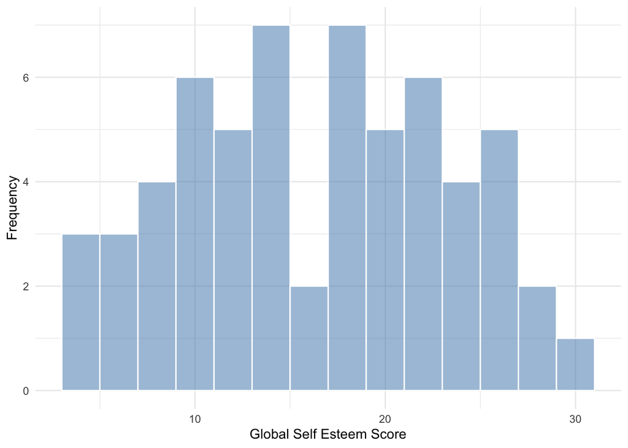

Figure 1. Distribution of Global Self Esteem Score for Individuals With and Without Eating Disorders

```r
gf_histogram( ~ rsestotal, color = "white", fill = "steelblue", binwidth = 2, data = eating_disorder) +
  labs(x = "Global Self Esteem Score", y = "Frequency") +
  theme_minimal()
```

Looking at the distribution of global self esteem in Figure 1 by adjusting the binwidth to 2 (there’s no unit of measure for global self esteem) there are some interesting patterns that arise. There is this massive dip in frequency at the self esteem scores of about 14-16, and then the most prominent and identical peaks of a frequency of 7 are at about self esteem scores of 12-14 and 16-18. Interestingly, then there is another dip on each side where the frequency goes to 5 at global self esteem scores of 10-12 and 20-22, a slight rise to a frequency of 6 on both sides again at global self esteem scores of 10-12 and 22-24. And then finally, one more identical drop on both sides to a frequency of four at global self esteem scores of 8-10 and 22-24. Without these major dips of frequency throughout the graph you could maybe say it’s somewhat of a normal curve, however, due to the dips I wouldn’t necessarily say this is a normal bell curve.

```r
get_correlation(rsestotal ~ bmi, data = eating_disorder, na.rm = TRUE)
```

```
## # A tibble: 1 × 1
##     cor
##   <dbl>
## 1 0.261
```

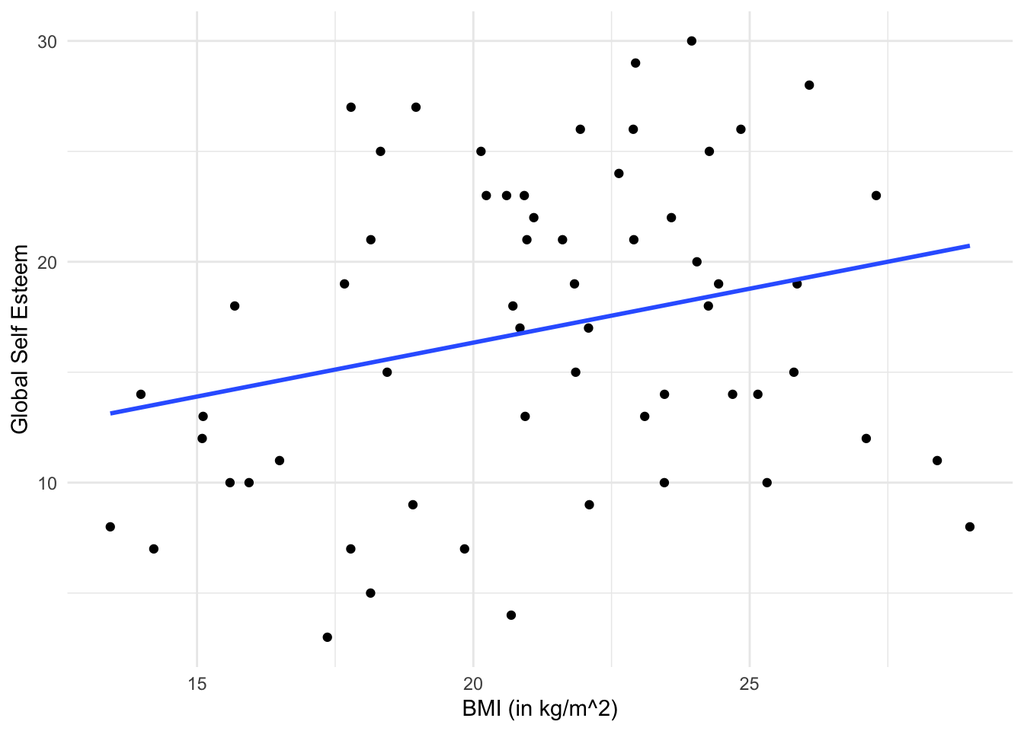

Figure 2. Scatterplot of relationship between rsestotal and bmi

```r
gf_point(rsestotal ~ bmi, data = eating_disorder) +
  geom_smooth(method = "lm", se = FALSE) +
  labs(x = "BMI (in kg/m^2)", y = "Global Self Esteem") +
  theme_minimal()
```

In Figure 2, we generated a scatterplot to see the overall relationship between our numerical outcome variable *rsestotal* (global self esteem) and our numerical explanatory variable *bmi* (body mass index). Overall as the individuals bmi increased, there was an associated increase in global self esteem. Consistent with this relationship is a weak positive correlation coefficient of 0.261. Important to note though that the correlation between this variable is not very strong.

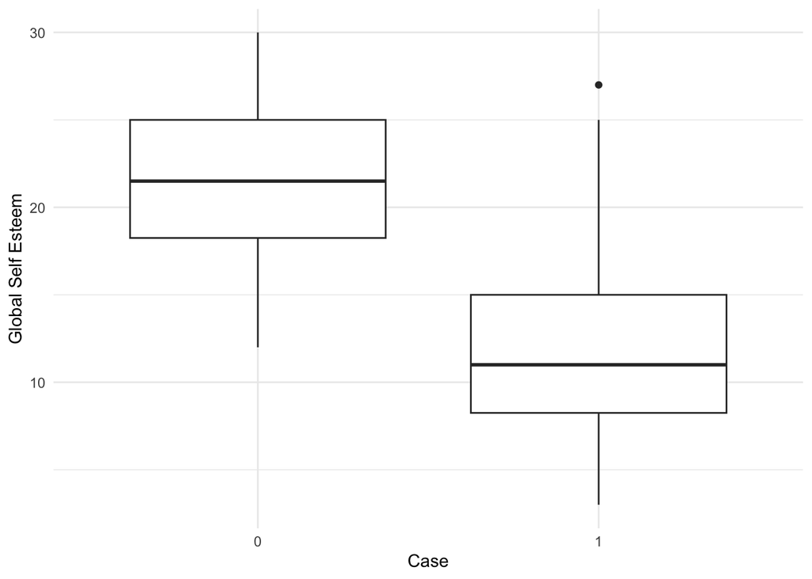

Figure 3. Boxplot of the relationship between cases and rsestotal of individuals

```r
eating_disorder$case = factor(eating_disorder$case)
gf_boxplot(rsestotal ~ case, data = eating_disorder) +
  labs(x = "Case", y = "Global Self Esteem") +
  theme_minimal()
```

In Figure 3, the non eating disorder individuals have significantly higher global self esteem scores than the eating disorder individuals. It looks like the the boxplot for the non eating disorder individuals is almost symmetrical while the boxplot for the eating disorder indviduals is right skewed. there also is an outlier of 27 for the eating disorder group.

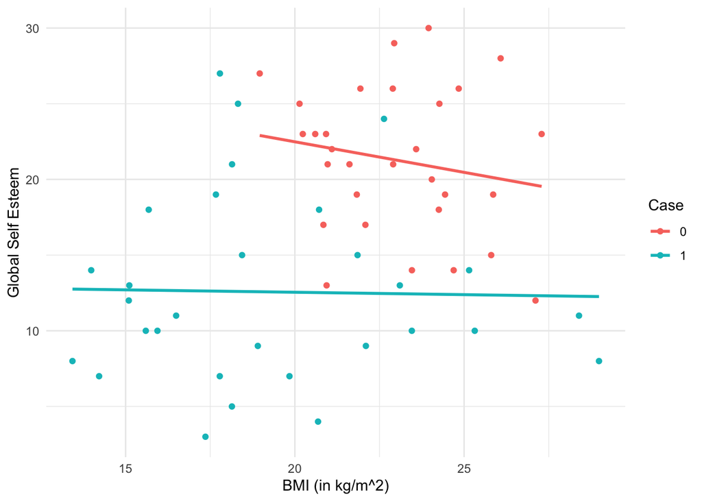

Figure 4. Colored scatterplot of relationship between global self esteem and bmi and case

```r
gf_point(rsestotal ~ bmi, color = ~ case, data = eating_disorder) +
  geom_smooth(method = "lm", se = FALSE) +
  labs(x = "BMI (in kg/m^2)", y = "Global Self Esteem", color = "Case") +
  theme_minimal()
```

```r
eating_disorder_case_0 = filter(eating_disorder, case == "0")
eating_disorder_case_0_cor = cor(rsestotal ~ bmi, data = eating_disorder_case_0)
eating_disorder_case_0_cor
```

```
## [1] -0.181806
```

```r
eating_disorder_case_1 = filter(eating_disorder, case == "1")
eating_disorder_case_1_cor = cor(rsestotal ~ bmi, data = eating_disorder_case_1)
eating_disorder_case_1_cor
```

```
## [1] -0.02125769
```

## 3.1 Methods

The components of our multiple linear regression model are the following:

- Outcome variable *y* = Global Self Esteem (no unit of measure)
- Numerical explanatory variable *x1* = BMI (in kg/m^2)
- Categorical explanatory variable *x2* = Case (0 = No Eating Disorder, 1 = Eating Disorder)

## 3.2 Model Results

Table 2. Regression table of linear model of global self esteem as a function of bmi and diagnosis case.

```r
eating_disorder_model = lm(rsestotal ~ bmi + case, data = eating_disorder)
get_regression_table(eating_disorder_model)
```

```
## # A tibble: 3 × 7
##   term      estimate std_error statistic p_value lower_ci upper_ci
##   <chr>        <dbl>     <dbl>     <dbl>   <dbl>    <dbl>    <dbl>
## 1 intercept   23.9       5.21      4.59    0       13.5     34.3
## 2 bmi         -0.113     0.222    -0.512   0.611   -0.558    0.331
## 3 case: 1     -9.12      1.66     -5.51    0      -12.4     -5.80
```

## 3.4 Inference for multiple regression

Using the output of our regression table we’ll test the null hypothesis for our numerical explanatory variable. The null hypothesis is that there is no relationship between global self esteem and bmi (the population slope is zero).

- H_0: beta_bmi = 0; H_A: beta_bmi ≠ 0

There appears to be a negative relationship between the bmi and global self esteem *after controlling for case*, (slope of -0.113). Furthermore, it seems to be a not very meaningful relationship since in Table 2 we see

- the 95% confidence interval for the population slope is (-0.558, 0.331), which is both on the negative and positive side.
- the p-value > 0.05 is rather big, so we fail to reject the null hypothesis that the population slope is zero in favor of the alternative.

We can also see that the coefficient for the `case` level is statistically significant and include confidence intervals entirely on the *negative* side, which means that, after controlling for *bmi*, the eating disorder individuals have average global self esteem scores that are significantly different from those of non eating disorder individuals (i.e., the coefficient is significantly different from zero).

## 3.5 Residual Analysis

We conducted a residual analysis to see if there was any systematic pattern of residuals for the statistical model we ran. Because if there are systematic patterns, then we cannot fully trust our confidence intervals and p-values above.

Our residual analysis consisted of (1) a residual histogram to check for normality of the residuals, (2) a scatterplot of residuals against the fitted (predicted) values, (3) a scatterplot of the residuals against bmi, and (4) side-by-side boxplots of the residuals for each case (eating disorder/non-eating disorder group).

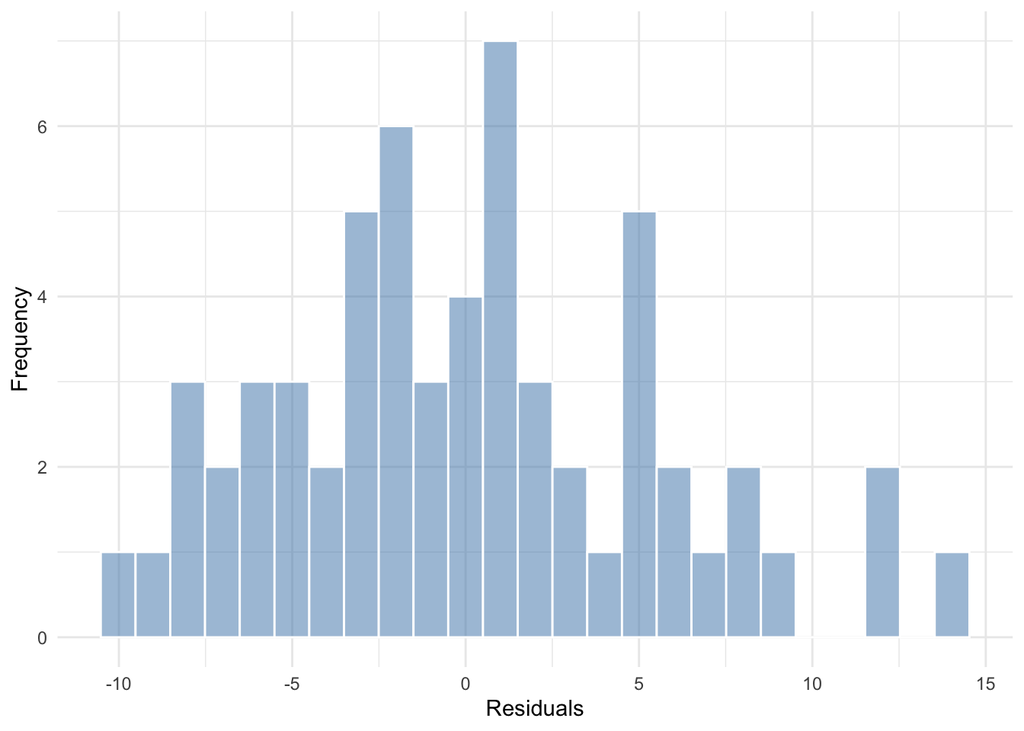

Figure 5. Histogram of residuals for the linear model

```r
residual_table = get_regression_points(eating_disorder_model)

gf_histogram( ~ residual, color = "white", fill = "steelblue", data = residual_table) +
  labs(x = "Residuals", y = "Frequency") +
  theme_minimal()
```

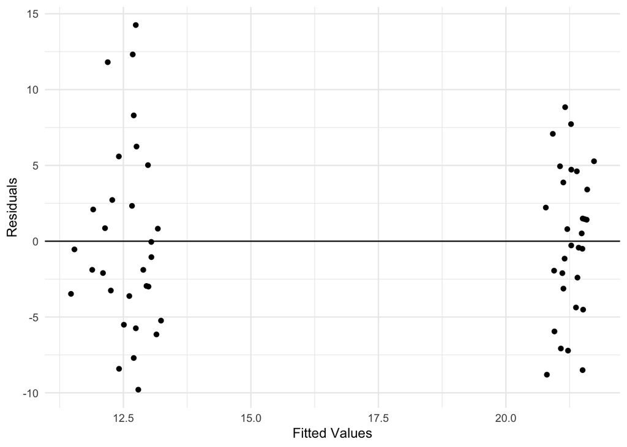

Figure 6. Scatterplot of Residuals against the fitted values

```r
gf_point(residual ~ rsestotal_hat, data = residual_table) +
  geom_hline(yintercept = 0) +
  labs(x = "Fitted Values", y = "Residuals") +
  theme_minimal()
```

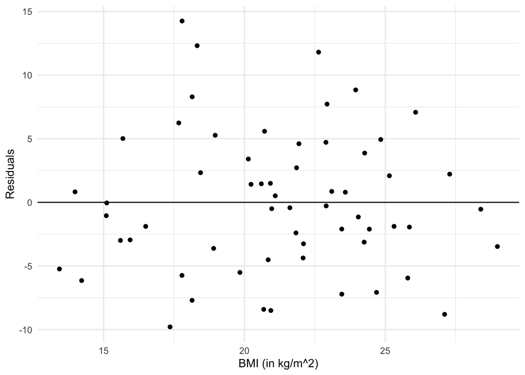

Figure 7. Scatterplot of Residuals against bmi

```r
gf_point(residual ~ bmi, data = residual_table) +
  geom_hline(yintercept = 0) +
  labs(x = "BMI (in kg/m^2)", y = "Residuals") +
  theme_minimal()
```

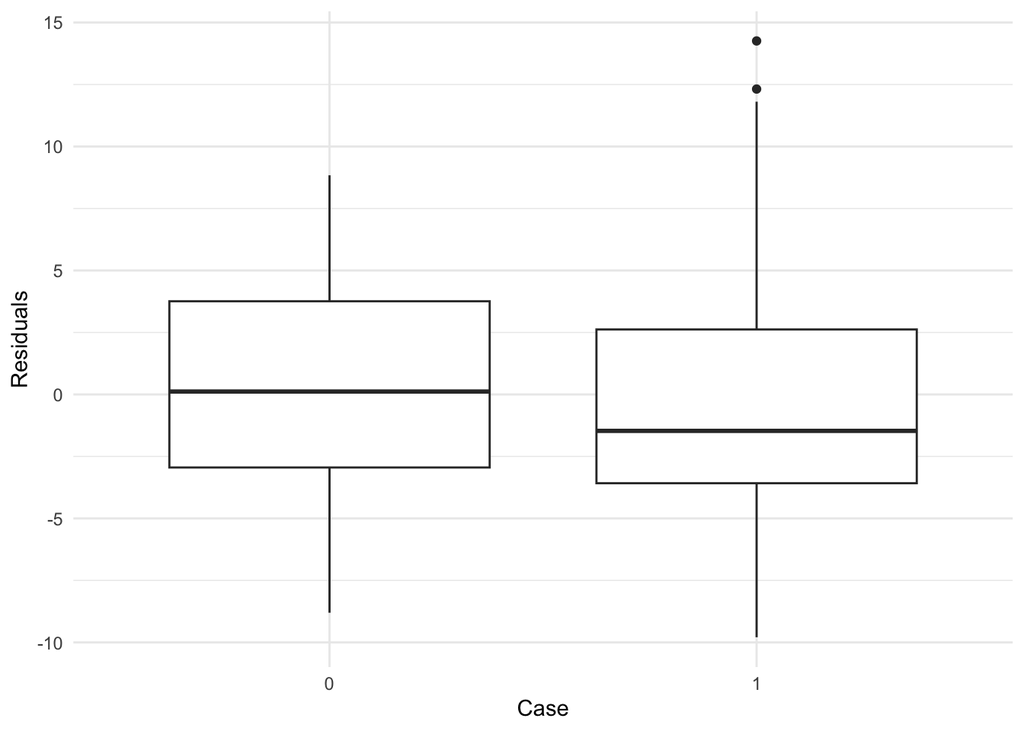

Figure 8. Boxplot of residuals for each case (0 = non-eating disorder individuals, 1 = eatig disorder individuals

```r
gf_boxplot(residual ~ case, data = residual_table) +
  labs(x = "Case", y = "Residuals") +
  theme_minimal()
```

In Figure 5 the histogram is nearly normal where there are some dips, but the shape is closer to a bell curve versus a skewed distribution.

In Figure 6 for the scatterplot of residuals against fitted values, the variability is not consistent where for the fitted values of around 11-13.5 the residuals are much more then the residuals around the fitted values of around 20 onwards.

This corresponds to Figure 7, where there is a high degree of variability. There seems to be a lower variability in residuals up till about a bmi of 17; then between bmi’s 17 and 25 there is significantly more variance in residuals and finally, at a bmi of 25 and over there seems to be an decrease in variability again.

In Figure 8 the boxplots of the two cases are different. The non eating disorder boxplot is almost symmetrical, but not quite where it is slightly right skewed. While the eating disorder boxplot is extremely right skewed.

Overall this dataset does not meet the conditions of a regression model, so the findings of this regression analysis should be interpreted with caution.

## Conclusions

Overall we found that there is not much association between global self esteem and bmi in eating disorder and non eating disorder individuals. After controlling for cases there seemed to be a decrease in global self esteem of 0.113 for every 1 kg/m^2 increase in bmi.

In general I was slightly disappointed in the fact that there wasn’t much correlation between global self esteem and bmi as somehow I thought that there could be this sort of sweet spot where all the sudden an individual had better global self esteem, but I do think it would be important to see if any of the other variables in the original dataset had any clear correlation with global self esteem.

## References

Helen Bould, Catherine Harmer, Rebecca Park, Ian Penton-Voak, Marcus Munafo, Matthew Broome (2020): How women with and without eating disorders perceive their own and others’ bodies: a case-control study. Accessed March 2021. https://doi.org/10.5523/bris.10pmme2kf4swp2rk58d9vuhwve